# Prosper Loan Analysis by John McGuigan

```
##                    ListingKey     ListingNumber
##  17A93590655669644DB4C06:     6   Min.   :      4
##  349D3587495831350F0F648:     4   1st Qu.: 400919
##  47C1359638497431975670B:     4   Median : 600554
##  8474358854651984137201C:     4   Mean   : 627886
##  DE8535960513435199406CE:     4   3rd Qu.: 892634
##  04C13599434217079754AEE:     3   Max.   :1255725
##  (Other)                :113912
##  ListingCreationDate            CreditGrade    Term
##  Min.   :2005-11-09 20:44:00          :84984   12: 1614
##  1st Qu.:2008-09-19 10:02:00   C      : 5649   36:87778
##  Median :2012-06-16 12:37:00   D      : 5153   60:24545
##  Mean   :2011-07-09 08:06:53   B      : 4389
##  3rd Qu.:2013-09-09 19:40:00   AA     : 3509
##  Max.   :2014-03-10 12:20:00   HR     : 3508
##                                (Other): 6745
##                  LoanStatus      ClosedDate
##  Current              :56576   Min.   :2005-11-25 00:00:00
##  Completed            :38074   1st Qu.:2009-07-14 00:00:00
##  Chargedoff           :11992   Median :2011-04-05 00:00:00
##  Defaulted            : 5018   Mean   :2011-03-07 20:21:21
##  Past Due (1-15 days) :  806   3rd Qu.:2013-01-30 00:00:00
##  Past Due (31-60 days):  363   Max.   :2014-03-10 00:00:00
##  (Other)              : 1108   NA's   :58848
##   BorrowerAPR       BorrowerRate     LenderYield
##  Min.   :0.00653   Min.   :0.0000   Min.   :-0.0100
##  1st Qu.:0.15629   1st Qu.:0.1340   1st Qu.: 0.1242
##  Median :0.20976   Median :0.1840   Median : 0.1730
##  Mean   :0.21883   Mean   :0.1928   Mean   : 0.1827
##  3rd Qu.:0.28381   3rd Qu.:0.2500   3rd Qu.: 0.2400
##  Max.   :0.51229   Max.   :0.4975   Max.   : 0.4925
##  NA's   :25
##  EstimatedEffectiveYield EstimatedLoss   EstimatedReturn   ProsperScore
##  Min.   :-0.183          Min.   :0.005   Min.   :-0.183   Min.   : 1.00
##  1st Qu.: 0.116          1st Qu.:0.042   1st Qu.: 0.074   1st Qu.: 4.00
##  Median : 0.162          Median :0.072   Median : 0.092   Median : 6.00
##  Mean   : 0.169          Mean   :0.080   Mean   : 0.096   Mean   : 5.95
##  3rd Qu.: 0.224          3rd Qu.:0.112   3rd Qu.: 0.117   3rd Qu.: 8.00
##  Max.   : 0.320          Max.   :0.366   Max.   : 0.284   Max.   :11.00
##  NA's   :29084           NA's   :29084   NA's   :29084    NA's   :29084
```

[output cut: 201 more lines]

```
##  Debt Consolidation:58308   C      :18345   Min.   :   0.0441
##  Not Available     :16965   B      :15581   1st Qu.:  16.0321
##  Other             :10494   A      :14551   Median :  34.1945
##  Home Improvement  : 7433   D      :14274   Mean   :  64.6746
##  Business          : 7189   E      : 9795   3rd Qu.:  74.8130
##  Auto              : 2572   (Other):12307   Max.   :2049.1803
##  (Other)           :10976   NA's   :29084
##      Profit         ProfitFraction
##  Min.   :-35000.0   Min.   :-1.5960
##  1st Qu.: -7851.1   1st Qu.:-0.8633
##  Median : -2180.5   Median :-0.4928
##  Mean   : -4222.9   Mean   :-0.3827
##  3rd Qu.:   417.3   3rd Qu.: 0.1047
##  Max.   : 15267.5   Max.   : 1.2623
##
```

# Univariate Plots Section

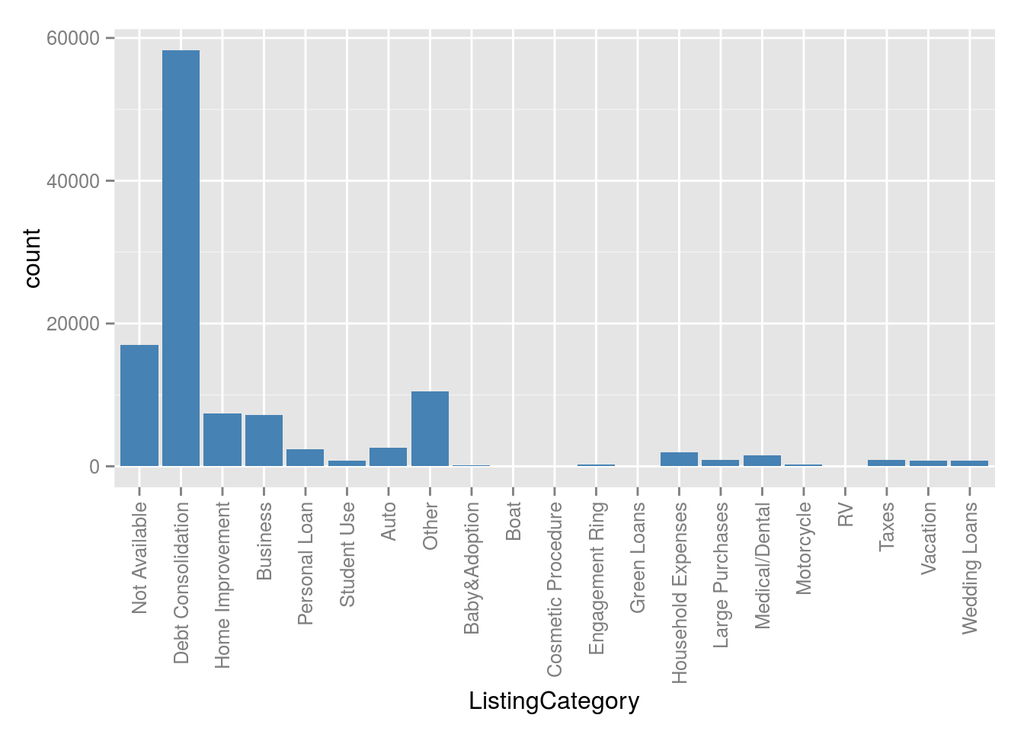

Most loans are for debt consolidation. A surprising number have no informative information (“Not Available” or “Other”) while the more unusual categories (like “Engagement Rings”) are rare.

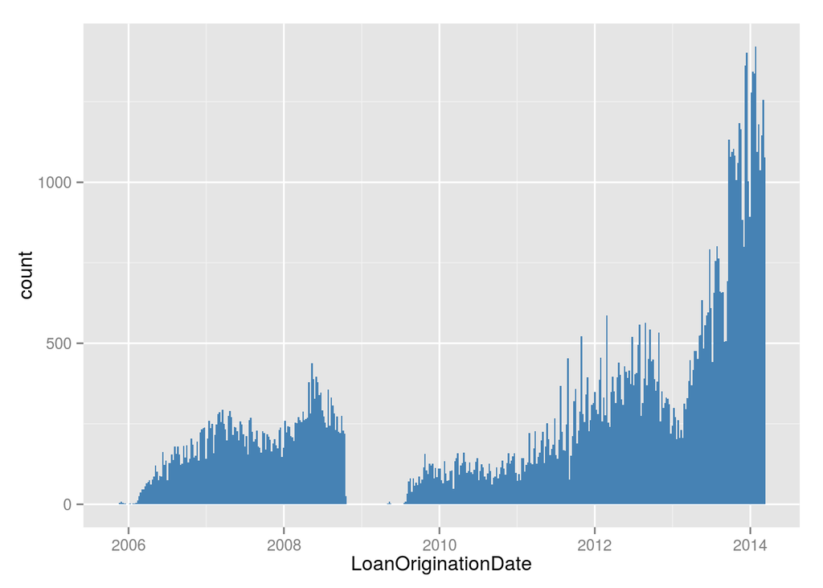

Looking at the date of loan origination, there seems to have been an abrupt halt in new loans for awhile- there was a period of time in 2009 where no loans were made. According to the company blog this was due to resolving legal issues with the SEC.

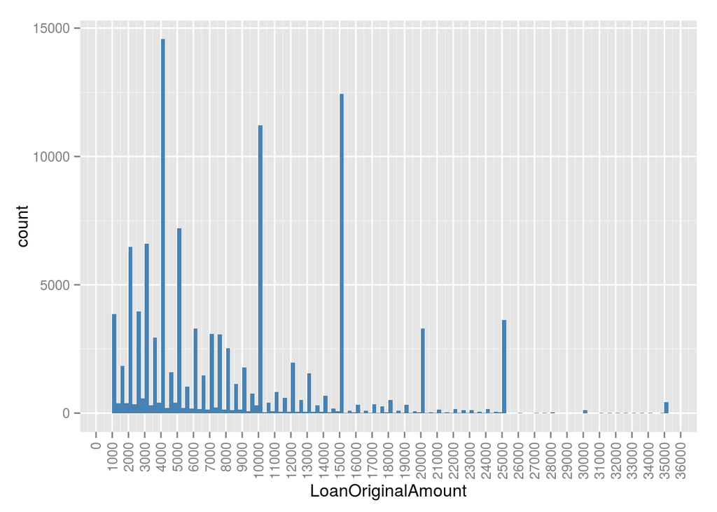

There was a clear “round number” effect in the amount of money in the loans. It seems likely that people creating the loan listings didn’t have an exact amount they needed, so they rounded to the nearest $500, $1000, or $5000.

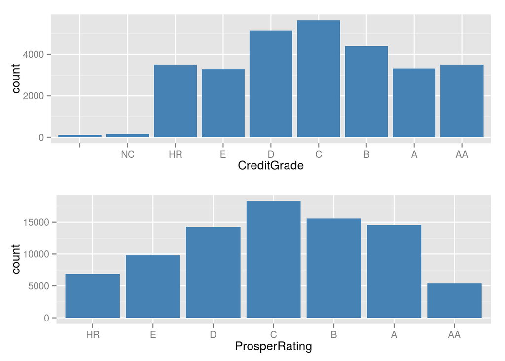

These are two highly similar variables but they can’t be merged since some were pre-2009 and some were post-2009. The more current rating (‘Prosper Rating’) seems much more normal.

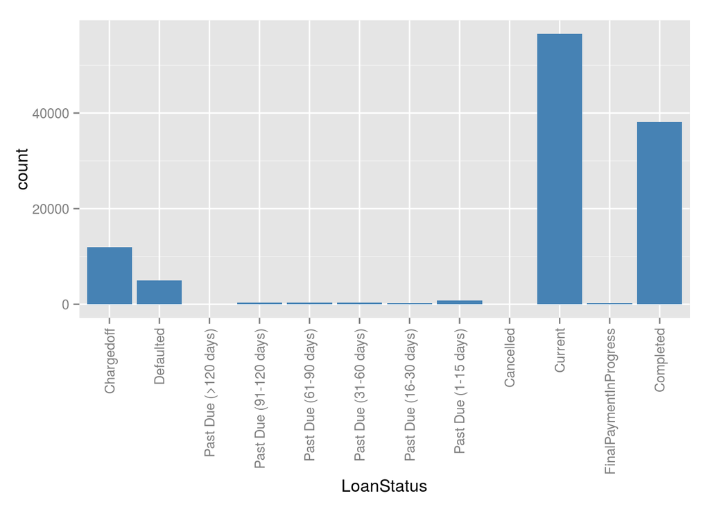

The majority of loans are complete or current (good) but a small portion are charged off, in default, or past due.

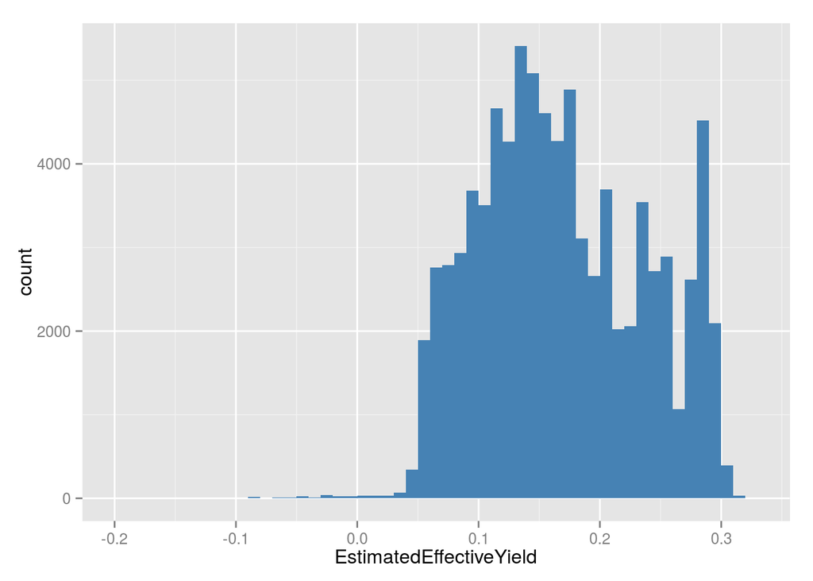

Estimated yield on the loans. A small amount had a 0 or negative yield, possibly highly risky loans. This is another variable that is only applicable to more recent loans.

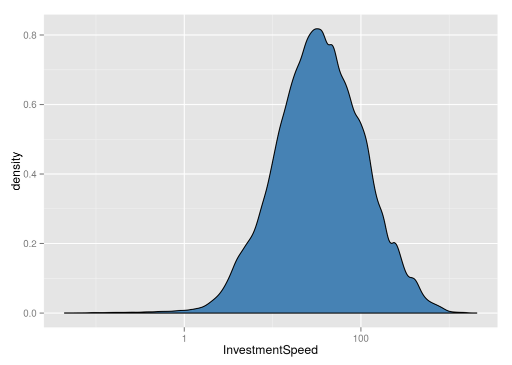

This is a look at the custom variable of investment speed- the total amount of the loan divided by the number of hours it took to go from listing the loan to it being originated. It is a normal distribution once the scale is tranformed by log10.

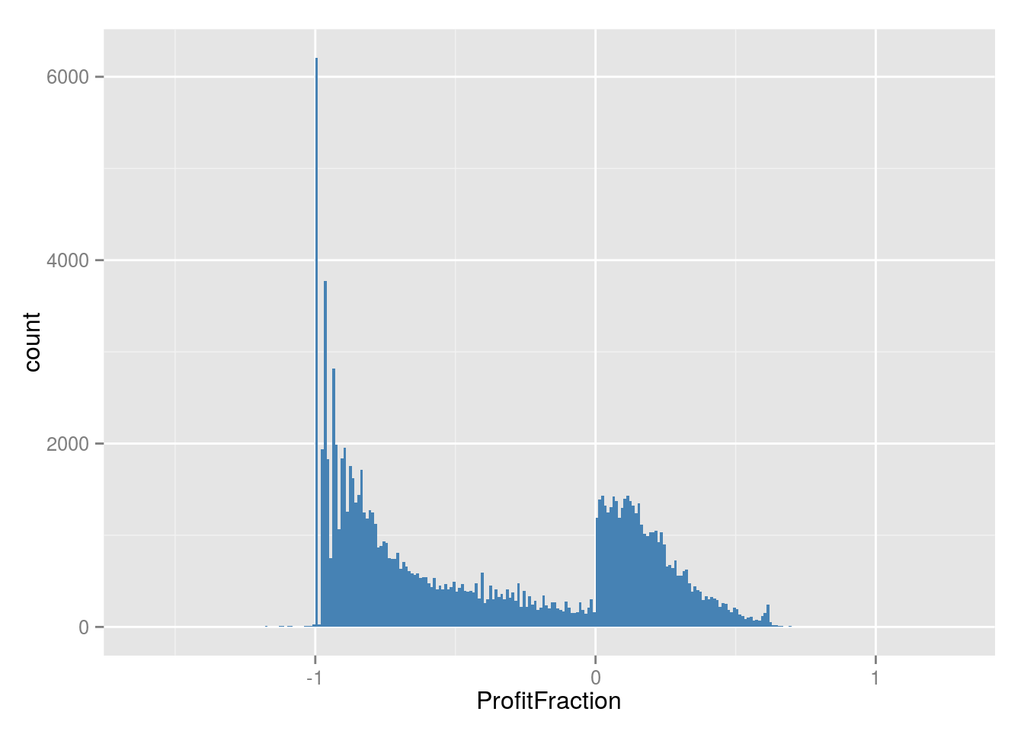

This is another custom variable looking at total lender profit compared to the initial amount invested for each loan. The amounts below 0 have not yet paid back the principal amount plus lender fees (servicing fees and collection fees).

# Univariate Analysis

### What is the structure of your dataset?

After some minor reworking of variables, the dataset consists of 113,937 observations of 84 variables for loans roughly between November 2005 and March 2014.

### What is/are the main feature(s) of interest in your dataset?

I’m looking at the data from the perspective of a borrower deciding which loans to invest in. This means I’d like to use different variables to determine the loan status or profitability (which is the key feature of interest).

### What other features in the dataset do you think will help support your investigation into your feature(s) of interest?

I could try looking at variables describing the loan (amount, term, borrower rate) and the borrower (ratings, credit scores, income) in order to find relationships between those and the final outcome.

### Did you create any new variables from existing variables in the dataset?

I created 3 variables:

- InvestmentSpeed = Loan amount divided by the difference between the listing date and the loan origination date in hours.
- Profit = Gross borrower payments minus lender payments (Initial principal amount and servicing/collection fees)
- ProfitFraction = Profit divided by the original loan amount

### Of the features you investigated, were there any unusual distributions? Did you perform any operations on the data to tidy, adjust, or change the form of the data? If so, why did you do this?

The ListingCreationDate seemed strange- for a period of time in 2008-2009 there were no loans made. Research indicates that Prosper temporarily shut down and then relaunched in July of 2009 with stricter requirements in order to reduce the rate of loans being defaulted on.

Dates were converted into POSIXct format with some rounding. For example, it isn’t necessary to keep accurate minute and seconds for LoanOriginationDate. Several variables were ordered (CreditGrade), relabeled (ListingCategory), or converted into factors (term) in order to simplify analysis. Two variables for Prosper Rating were replaced with a single ordered factor variable since they were different labels for the same thing.

# Bivariate Plots Section

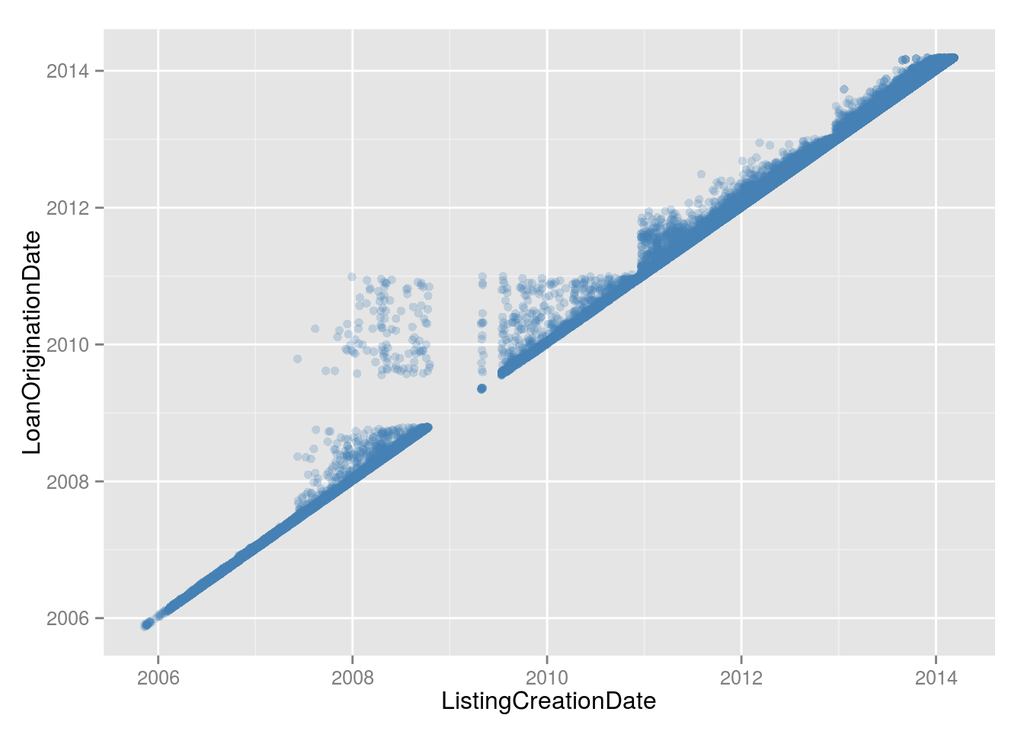

```
## Time difference of 194.45 hours
```

This is a look at the investment speed over time. The median time difference was about 195 hours. There does seem to be some time periods (especially around the 2009 halt) where the difference was much greater. It would be interesting to see if loans that end up being good values (high yield relative to risk) are funded faster.

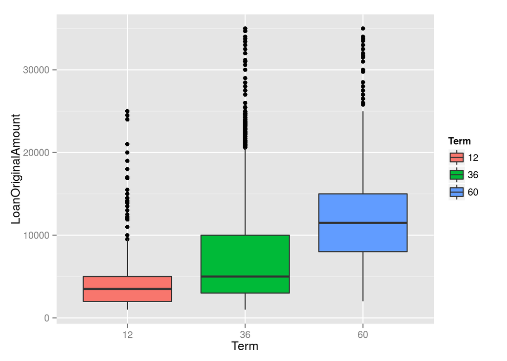

As expected, a larger term is associated with larger loans.

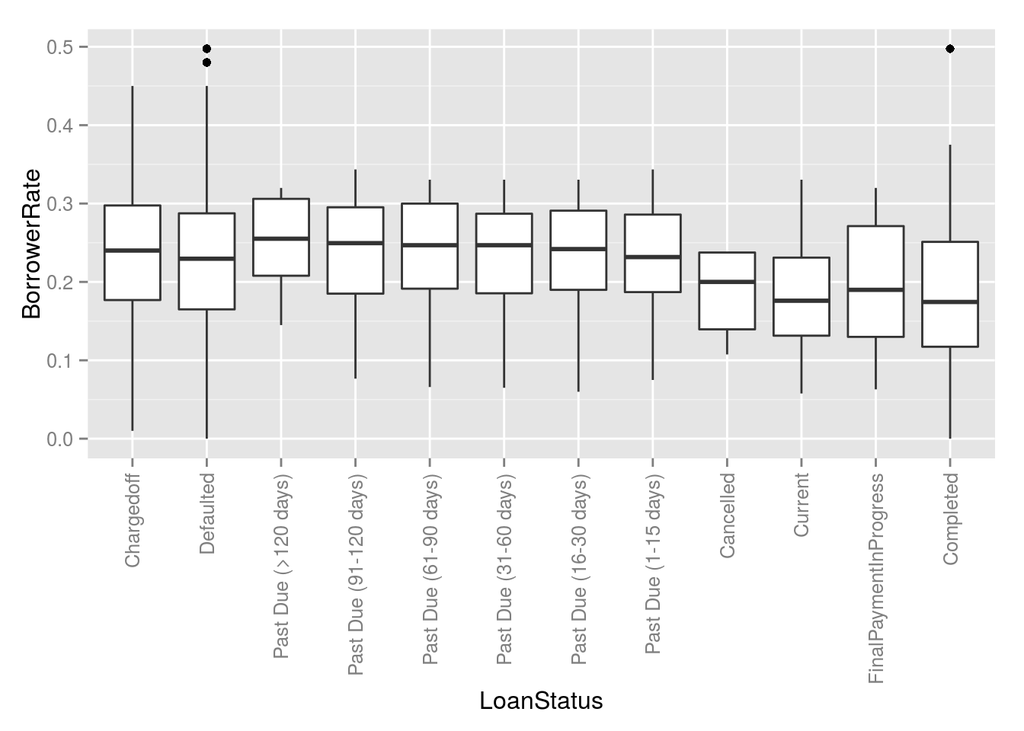

Loans with “good” statuses seem to have slightly lower borrower rates. Creditworthiness could be a confounding variable- good borrowers get lower rates are less likely to default.

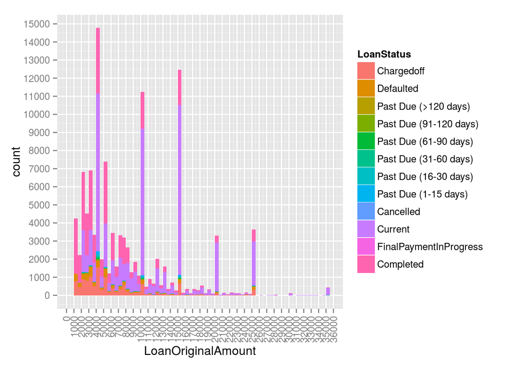

It seems like there may be a slight tendency for small loans to be more likely to go bad (default/chargedoff). It also looks like the minimum loan amount might have been raised (there are no current loans between $1000 and $2000).

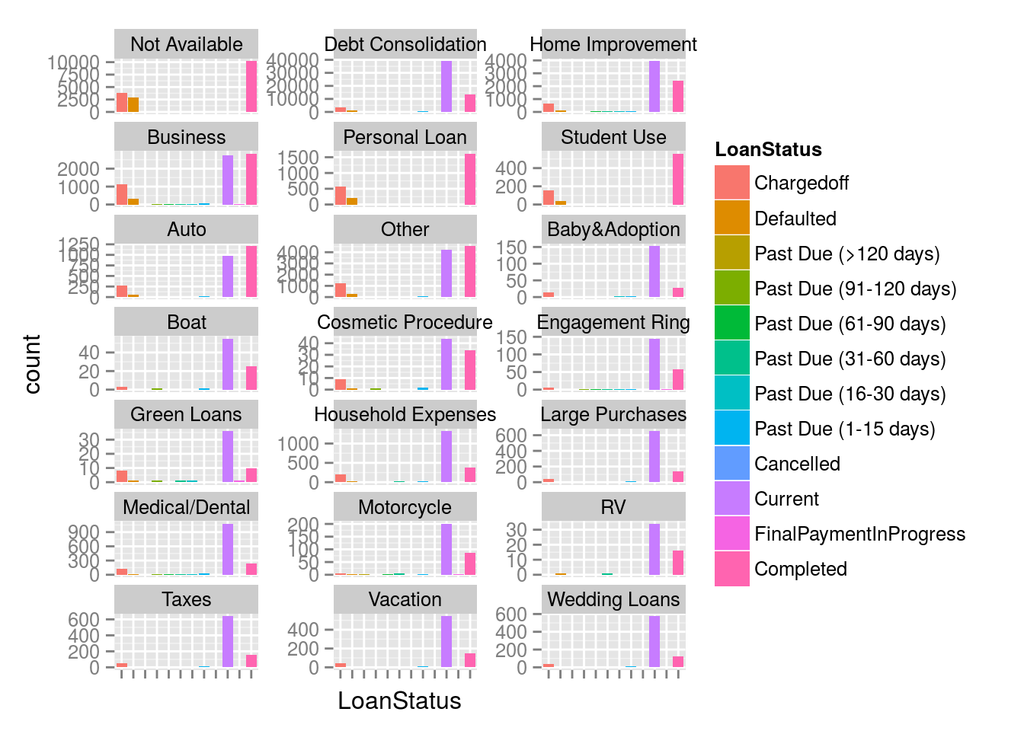

Color was added for easier visualization here. It looks like there are no more “Not Available”, “Personal Loan”, or “Student Use” loans since all of these seem to be finished (completed, defaulted, or charged off).

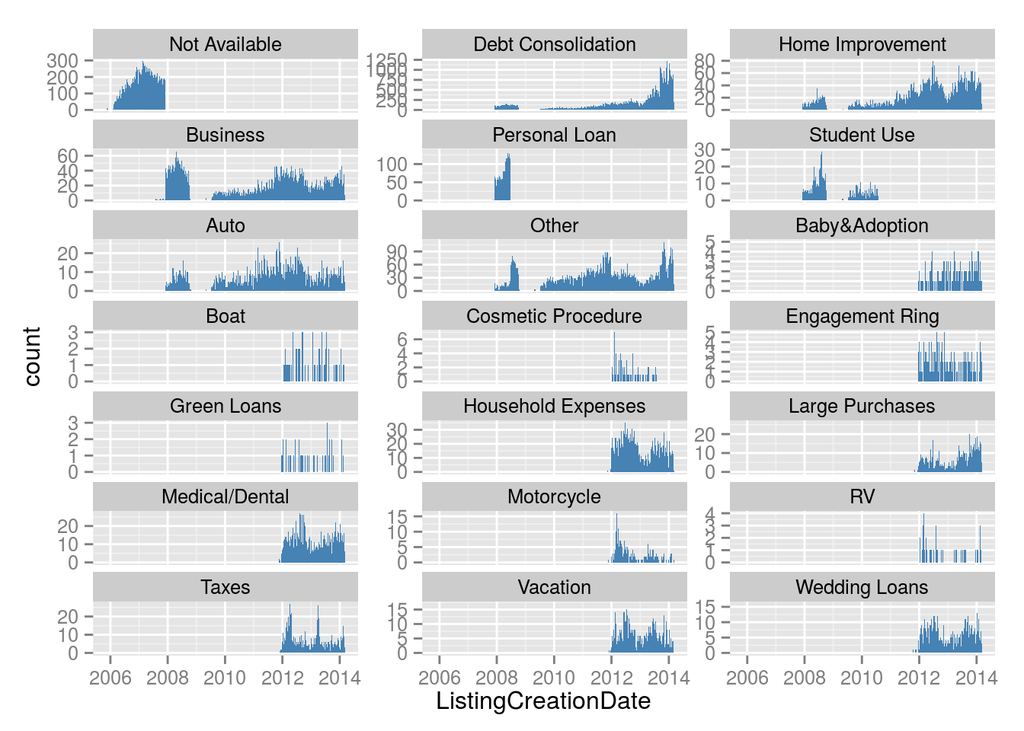

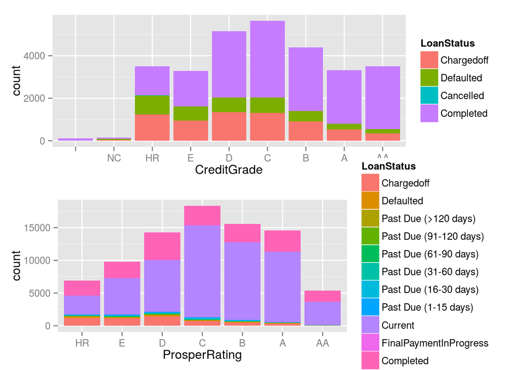

The credit rating system was clearly improved after Prosper started back up. Previously even “AA” ratings had a significant portion of “bad” loans- perhaps 1 in 8 loans are in default or were charged off. In the newer rating system very few loans with that rating have that status (although most are still current and may end up in default or charged off).

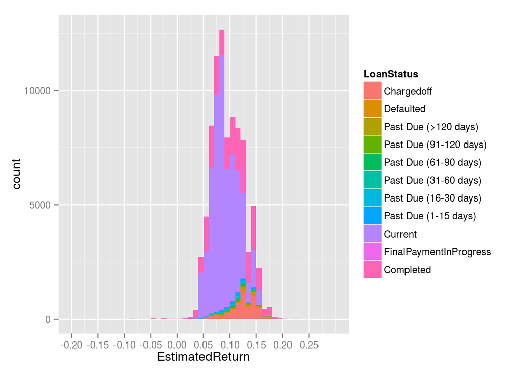

There certainly seems to be a strong relationship between status and estimated return. Higher estimated return loans have higher rates of bad loan statuses (larger reward for riskier loans).

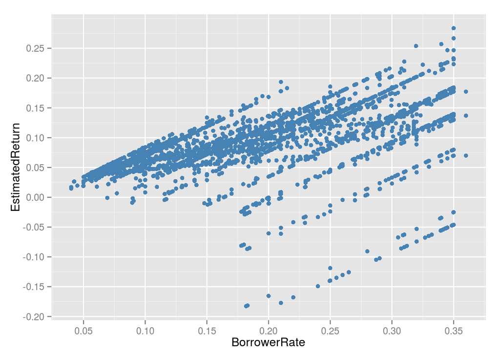

This distribution is very interesting. As expected, there is a clear linear pattern between estimated return and borrower rate- if the borrower pays more in interest the lender expects to makes more money. However, there are several such linear relationships. Probably due to different categories of loans (amount, term, APR, credit, etc).

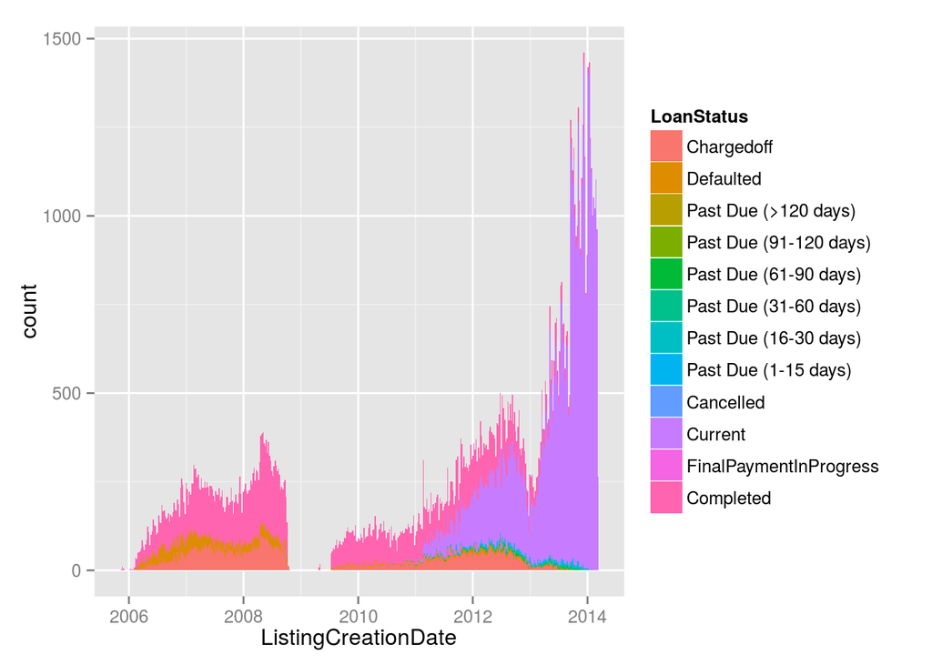

Obviously a large number of the most recent loans are current (since they haven’t had time to change status) but it does seem that the re-launch of Prosper has had lower rates of default than the previous version.

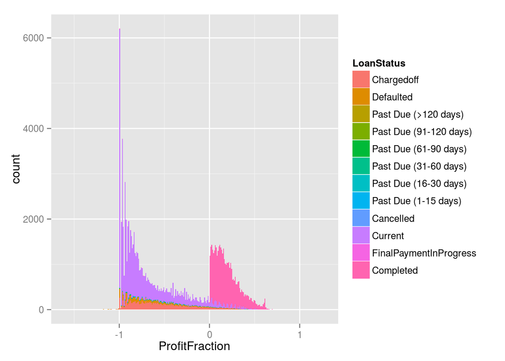

# Bivariate Analysis

### Talk about some of the relationships you observed in this part of the investigation. How did the feature(s) of interest vary with other features in the dataset?

The Loan status was compared to several variables since the main goal of any investor would be to avoid investing in a loan that would result in a loss. Most relationships were unsurprising- loans that are current or paid off have a slightly lower borrower interest rate, better credit ratings, and lower estimated returns.

### Did you observe any interesting relationships between the other features (not the main feature(s) of interest)?

The listing category was very interesting to look at over time. It’s very easy to see both how the categories have changed over time and their relative popularity. For example, there aren’t many people trying to obtain loans for RVs (0 to 4 lisitings per week).

### What was the strongest relationship you found?

I think the estimated return and loan status relationship was the strongest one that was relevant. Risky loans have higher estimated payoff while safer loans make less money.

# Multivariate Plots Section

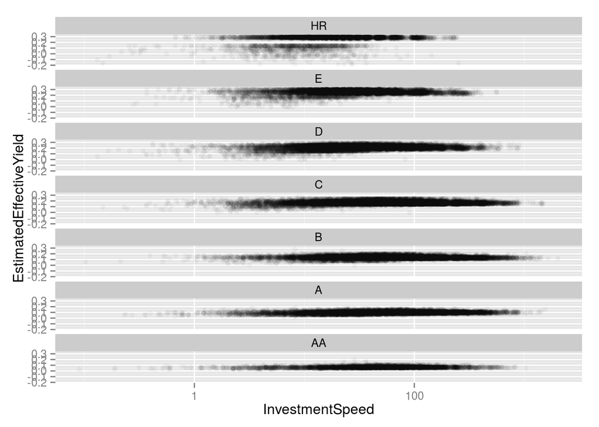

It seems that loans with higher ratings are invested in much more quickly, but as the rating increases the estimated yield is lower and investment slows down.

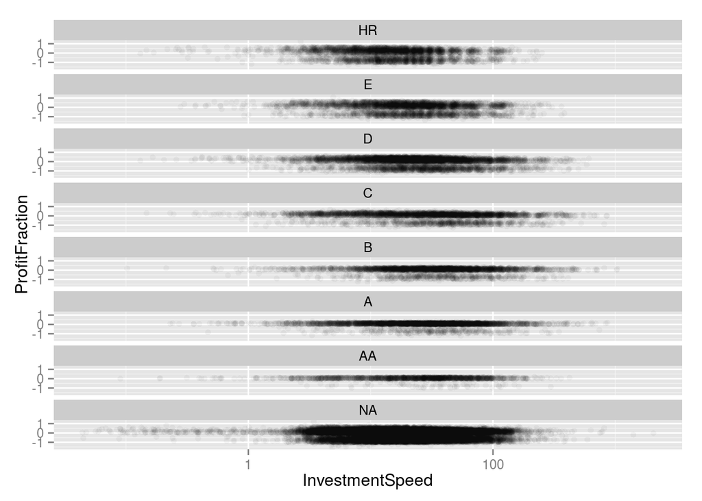

However, investment speed doesn’t show a clear relationship with final profitability (after the loan closes).

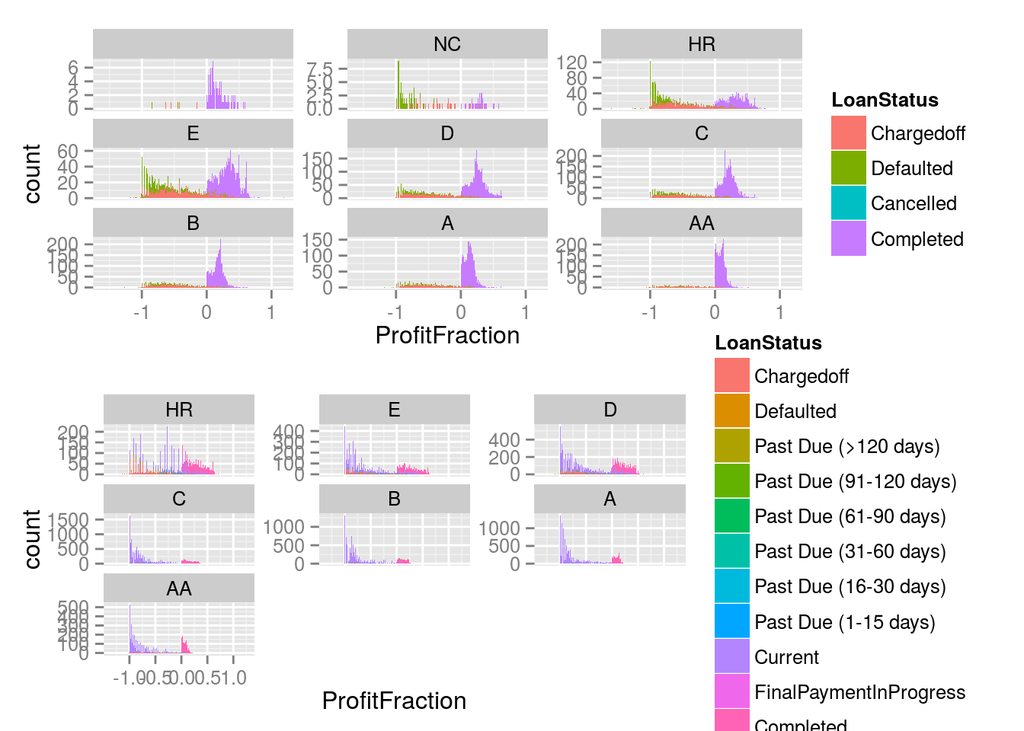

These two sets of graphs show the relationship between profit fraction, credit rating, and current status. Higher credit rations (original or new ProsperRating) have a lower profit fraction among completed loans, but fewer loans are completed with a negative profit fraction.

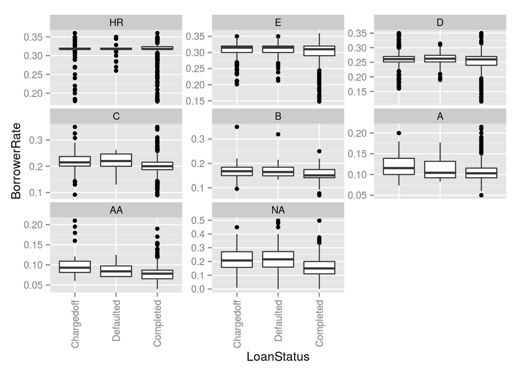

This plot makes it easy to see how borrowers with better credit get a lower APR, and that defaulted or chargedoff loans tend to have a higher rate for the borrower. This is more obviously apparent when the borrower has a higher credit rating.

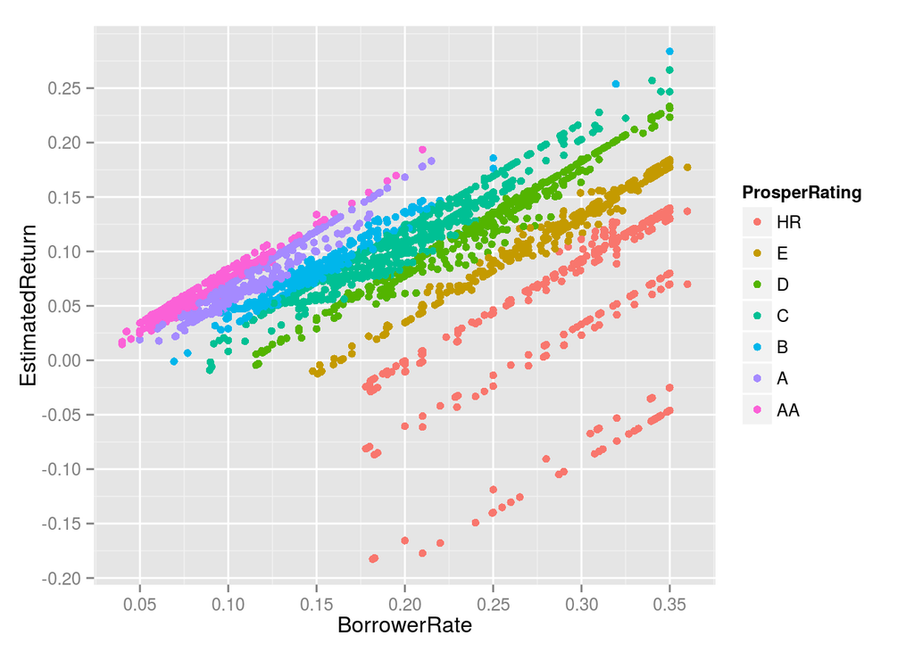

The Prosper Rating (or related variables) definitely seems to account for a large part of the difference here. Possibly due to a higher estimated chance of the loan defaulting, or different loan amounts or terms.

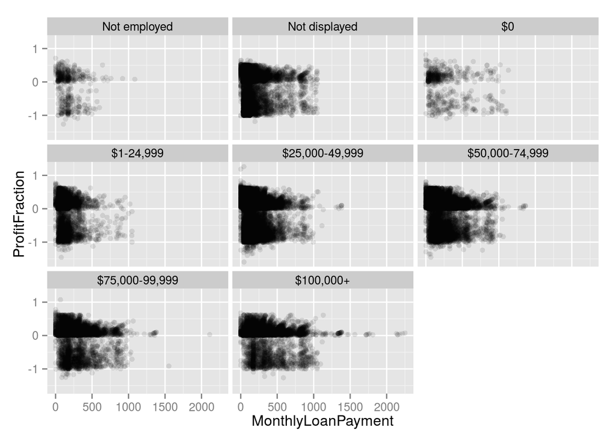

Interestingly, if the monthly loan payment was higher the loan was much more likely to be profitable (despite default/chargeoff). The same relationship is seen as the lender income increases.

# Multivariate Analysis

### Talk about some of the relationships you observed in this part of the investigation. Were there features that strengthened each other in terms of looking at your feature(s) of interest?

The first plot here seemed to show a very clear relationship. If we can look at investment speed as a measure of desireability, lenders tend to want safer loans (higher prosper ratings) but only up to a point, since they also want high returns (which very highly rated loans don’t provide). However, this doesn’t translate to actual profitability once the loan is over. There seems to be very clear (if unsurprising) relationship between risk (Prosper Rating as a meta-variable) and reward (profit) shown by the other graphs.

### Were there any interesting or surprising interactions between features?

I was surprised that a higher monthly loan tends to result in a more profitable loan. I would have expected that a higher monthly payment would have a greater risk of default.

### OPTIONAL: Did you create any models with your dataset? Discuss the strengths and limitations of your model.

A model would be difficult to create with this dataset, since the data has changed so much over time. I’d certainly only use data from after the launch, and idealy use data since 2012 when listing categories were changed. However, there hasn’t been enough time since then for loans to complete in order to get a complete picture of the data.

# Final Plots and Summary

### Plot One

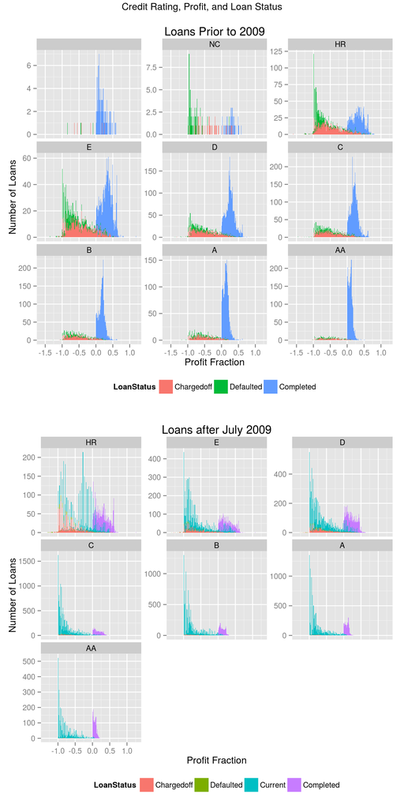

### Plot Two

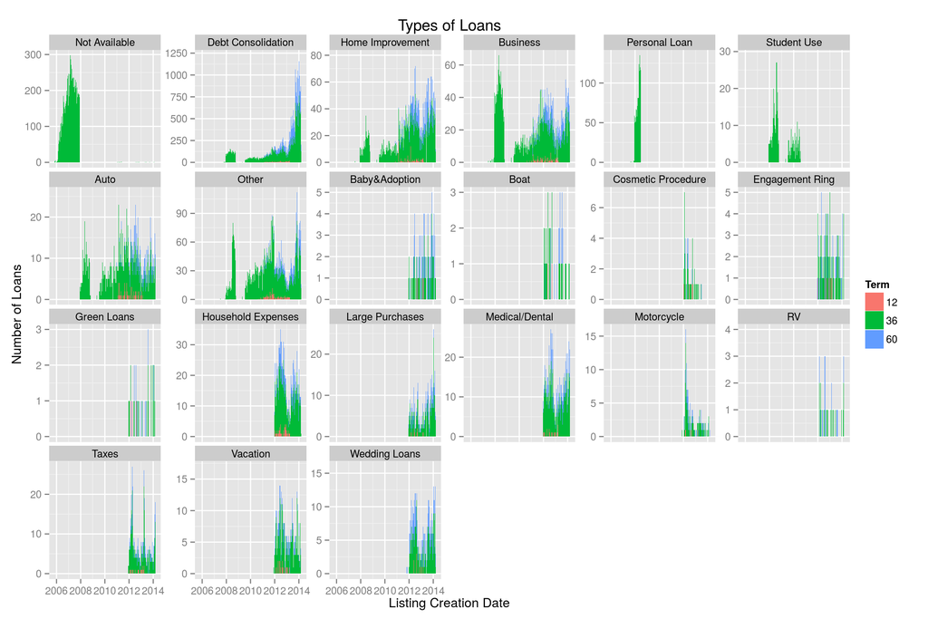

### Description Two

This plot shows a concise view of the kinds of loans that are listed on Prosper. It’s important to see that the listing categories and available loan terms have changed over time. Many of these have only been available recently (starting in 2012). By far Debt Consolidation is the most popular listing category, and 36-months is the most popular loan term.

### Plot Three

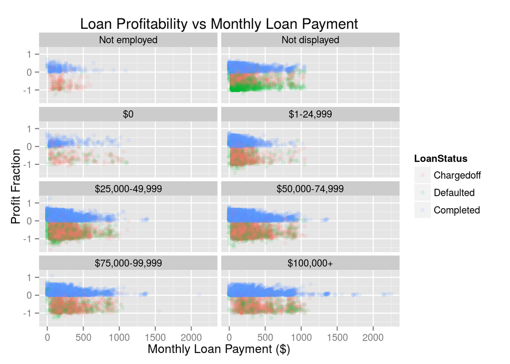

### Description Three

# Reflection

I did a lot of cleaning and organizing of the data before starting analysis. This was helpful for understanding the different variables even if I didn’t use all of them. I expected to see some tradeoff between risk and reward and certainly several of the plots showed this in different ways. However, it is difficult to simplify this relationship down to just a few variables.

The dataset was quite complex not only due to the large number of variables, but also because these variables changed over time. The entire Prosper system was shut down and restarted in 2009. This also involved a change in the credit rating variable (‘CreditRating’ vs ‘ProsperRating’) and policies (minimum loan amount, credit requirements, etc). The listing categories changed at multiple points in time also. However, I was able to get around some of these difficulties by dividing the dataset and making multiple plots. Additional data on the exiting current loans would be helpful. Many of the loans in the dataset are too new to draw judgements on since they are still current and may or may not end up in default.

If I were to further explore this dataset I could investigate several different additional groups of variables such as the many variables that involve the borrower’s credit rating, the data on borrowers’ other Prosper Loans, the invovlement of friends in the investment, and the group identities.